# Inferencia Bayesiana

En el enfoque Bayesiano consideramos un modelo probabilístico aleatorio, i.e. el conjunto de leyes de probabilidad $\mathcal{P}$ es aleatorio. Podemos considerar los siguientes ejemplos:

1) **Distribución empírica con ponderación Dirichlet** Sean datos observados $\left\{ X_i \right\}_{i=1}^n \stackrel{\text{i.i.d.}}{\sim}P_0$ y $\pmb{\alpha}\in\mathbb{R}_+^n$, consideramos el modelo

\begin{equation}\mathcal{P}=\left\{ \begin{aligned} & \text{ Distribuciones discretas de probabilidad con átomos} \\ & \text{únicamente en }X_1,,\ldots,X_n \text{ y respectivas masas de} \\ & \text{ probabilidad }w_1,\ldots,w_n\text{ con }\pmb{w}\sim\text{Dirichlet}(\pmb{\alpha}). \\ \end{aligned} \right\},\end{equation}

i.e. si $P\in\mathcal{P}$ entonces $P$ tiene una función de masa de probabilidad aleatoria asociada $$p(\cdot)=\sum_{i=1}^n w_i\delta_{X_i}(\cdot)$$ con $\pmb{w}\sim\text{Dirichlet}(\pmb{\alpha})$. Usualmente se toma $\alpha>0$ y $\pmb{\alpha}=(\alpha,\ldots,\alpha)$; el caso particular en que $\alpha=1$ se conoce como Boostrap Bayesiano.

2) **Modelo paramétrico general** Consideramos distribuciones de probabilidad parametrizadas por un valor $\pmb{\theta}\in\mathbb{\Theta}\subset \mathbb{R}^k$, para algún $k\geq 1$, y las denotamos como $\mathcal{P}_{\pmb{\theta}}$. Aleatorizamos $\theta\sim\Pi$ con $\Pi$ una distribución de probabilidad en $\mathbb{\Theta}$. Llamamos modelo probabilístico paramétrico Bayesiano a $$\mathcal{P}_{\text{Dist}(\pmb{\theta}),\,\theta\sim\pi}=\left\{ P_{\pmb{\theta}} \,:\, \theta\sim\Pi \right\}.$$

## Regla de Bayes

Supongamos que los datos toman valores en un espacio $\mathbb{X}$ con $\sigma$-álgebra $\mathcal{X}$. Consideramos un modelo probabilístico $\mathcal{P}_{\text{Dist}(\theta)}=\left\{ P_\theta \, : \, \theta \in \Theta \right\}$ tal que se satisface $P_\theta<<\mu$ $\forall \theta \in \Theta$ con $\mu$ una medidad en $(\mathbb{X},\mathcal{X})$ y denotamos $p_\theta = \mathrm{d}P_\theta/\mathrm{d}\mu$. Por otro lado asignamos una distribución $\Pi$ sobre $\theta \in \Theta$.

El par $(\theta,X)$ tiene función de densidad de probabilidad $p_\theta(x)$ respecto a la medida $\Pi\times \mu$

$$ \mathbb{P}\left[ X \in A, \theta \in B \right] = \int_A \int _B p_\theta(x)\Pi(\mathrm{d}\theta)\mu(\mathrm{d}x) $$

Entonces una versión de la densidad posterior de $\theta | X =x$ respecto de la medidad $\Pi(\mathrm{d}\theta)$ está dada por

$$ \frac{ p_\theta(x) }{ \int_\Theta p_\theta(x)\Pi(\mathrm{d}\theta) }. $$

Efectivamente

$$ \mathbb{P}\left[ \theta \in B \,|\, X =x \right] = \int_B \frac{ p_\theta(x) }{ \int_\Theta p_\theta(x)\Pi(\mathrm{d}\theta) } \mathrm{d}\Pi(\theta) $$

Ejemplos:

1) Si la medida de Lebesgue en $\Theta$ está dad por $\mathrm{d}\theta$ y se tiene que $\Pi(\mathrm{d} \theta)=\pi(\theta)\mathrm{d}\theta$, con $\pi$ una función de densidad de probabilidad en $\mathbb{\Theta}$, entonces se obtiene la densidad posterior respecto a $\mathrm{d}\theta$, $p_{\theta|X=x} \propto p_\theta(x)\pi(\theta).$

2) Si $\mathrm{d}\theta$ es la medida de conteo en $\mathbb{\mathbb{\Theta}}$ numerable entonces nuevamente $\Pi(\mathrm{d} \theta)=\pi(\theta)\mathrm{d}\theta$ con $\pi$ ahora una función de masa de probabilidad y se obtiene la función de masa posterior respecto a la medida de conteo $\mathrm{d}\theta$, $p_{\theta|X=x} \propto p_\theta(x)\pi(\theta)$.

### Ejemplos

1) Para la **distribución empírica con ponderación Dirichlet** denotamos $X_{(1)}<X_{(2)}<\ldots<X_{(k)}$ los valores únicos sin repeticiones de los datos, con $k\leq n$, $n_j=\#\left\{ i\,:\, X_i = X_{(j)}\right\}$, $\mu$ la medida de conteo en $\left\{ X_{(k)} \right\}_{j=1}^k$ y $\Pi=\mathcal{L}\left(\text{Dirichlet}(\pmb{\alpha}) \right)$ la distribución Dirichlet a priori en el simplejo $k-1$ dimensional $\mathbb{S}_{k-1} =\left\{ \left( w_{(1)},\ldots , w_{(k)} \right) \in [0,1]^k \, : \, \sum_{i=1}^k w_{(i)}=1 \right\} $; entonces la distribución posterior está dada por $$p_{\pmb{w}|\pmb{X}}\propto \prod_{i=1}^n w_i^{1+\alpha-1} = \prod_{j=1}^k w_{(j)}^{n_j+\alpha -1}.$$

Entonces dados datos $\pmb{X}$, $\pmb{w}$ a posteriori tiene nuevamente una distribución $\text{Dirichlet}$, en este caso el parámetro se actualiza a $\pmb{\alpha}+\pmb{1}$.

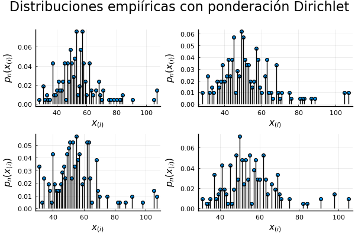

```julia
plt
```

### Ejemplos

2) Modelo paramétrico **Binomial-Beta**. Supongamos que tenemos una moneda con probabilidad $\theta\in[0,1]$ de que al ser lanzada caiga en "águila" y probabilidad $1-\theta$ de que caiga en "sol". Modelamos tal fenómeno con una variable $\text{Bernoulli}(\theta)$ y al número de $n=50$ lanzamientos independientes que caen en águila consecuentemente se modela con una $\text{Binomial}(n,\theta)$. Asignemos una distribución a priori $\theta\sim\text{Beta}(\alpha_0,\beta_0)$ entonces

\begin{align*} p_\theta(z) &=\binom{n}{z}\theta^z(1-\theta)^{n-z}, \\ \pi(\theta) & = \frac{\Gamma(\alpha)\Gamma(\beta)}{\Gamma(\alpha+\beta)}\theta^{\alpha-1}(1-\theta)^{\beta-1} \end{align*}

y por la regla de Bayes

$$ p_{\theta|Z=z}(\theta) \propto \theta^{z+\alpha-1}(1-\theta)^{n-z+\beta-1} $$

de lo cual se obtiene que $\theta|Z=z \sim \text{Beta}(z+\alpha,n-z+\beta)$.

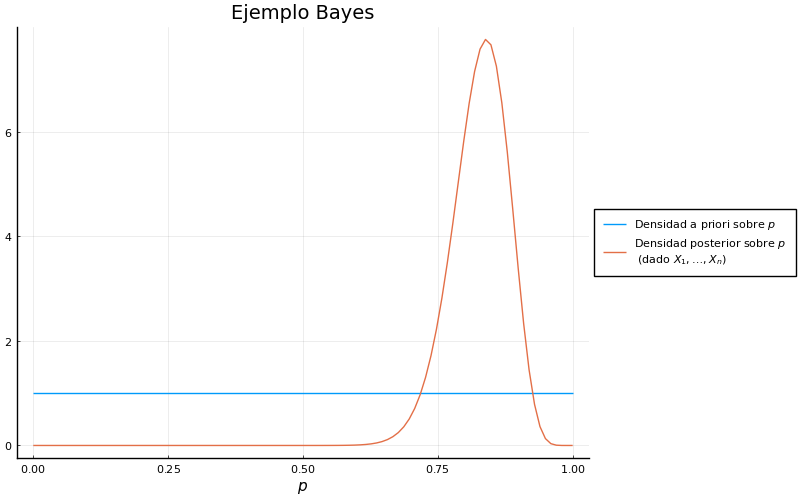

```julia
p
```

## Distribuciones conjugadas en modelos Bayesianos

Observemos que en el ejemplo anterior la distribución posterior sobre $\theta$ pertenece a la misma familia que la distribución a priori, en este caso la familia de distribuciones $\left\{ \text{Beta}(\alpha,\beta) \, : \, \alpha,\beta>0 \right\}$. Cuando la distribución posterior pertenece a la misma familia que la distribucón a priori decimos que estas son distribuciones conjugadas y que la distribución a priori es conjugada a priori para la verosimilitud, $p_\theta$.

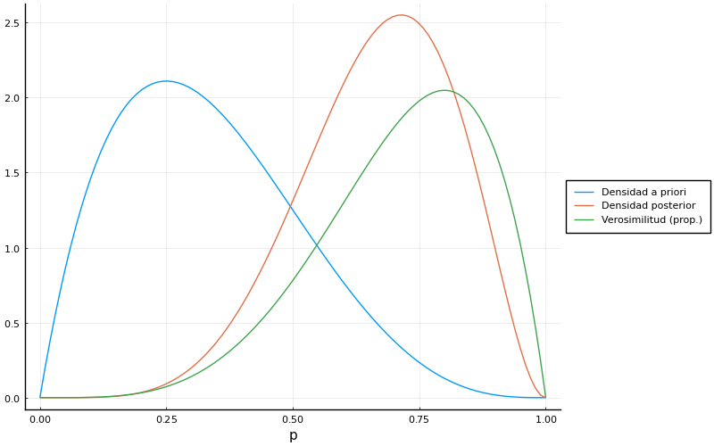

```julia
p
```

### Ejemplos

4) Modelo paramétrico Bayesiano Normal con varianza conocida y distribución a priori Normal en la media. Para observaciones i.i.d. con distribución común $\text{Normal}(\mu,\sigma^2)$ se tiene la verosimilitud

\begin{align*} p(\pmb{D}|\mu,\sigma^2)= \frac{1}{(2\pi)^{n/2}} \frac{1}{(\sigma^2)^{n/2}} \exp \left( - \frac{1}{2\sigma^2} \sum_{i=1}^n(x_i-\mu)^2 \right) \end{align*}

Si

$$ \pi(\mu)=\frac{1}{\sqrt{2\pi}} \frac{1}{s} \exp \left(- \frac{1}{2s^2} (\mu-m)^2\right) $$

Entonces

$$ \pi(\mu|\pmb{D},\sigma^2) \propto p(\pmb{D}|\mu,\sigma^2)\pi(\mu)\propto \exp\left( -\frac{\left( (\mu- \left(\frac{x}{\sigma^2}+\frac{m}{s^2}\right)\frac{\sigma^2s^2}{\sigma^2+s^2} \right)^2}{2\frac{\sigma^2s^2}{\sigma^2+s^2} } \right) $$

### Ejemplos

5) Modelo paramétrico Bayesiano Normal con distribución a priori **NormalGammaInversa**. Para observaciones i.i.d. con distribución común $\text{Normal}(\mu,\sigma^2)$ se tiene la verosimilitud

\begin{align*} p(\pmb{D}|\mu,\sigma^2)= \frac{1}{(2\pi)^{n/2}} \frac{1}{(\sigma^2)^{n/2}} \exp \left( - \frac{1}{2\sigma^2} \sum_{i=1}^n(x_i-\mu)^2 \right) \end{align*}

Se sigue que \begin{align*} p(\pmb{D}|\mu,\sigma^2)&= \frac{1}{(2\pi)^{n/2}} \frac{1}{(\sigma^2)^{n/2}} \exp \left( - \frac{1}{2\sigma^2} \sum_{i=1}^n(x_i-\mu)^2 \right) \\ & = \frac{1}{(2\pi)^{n/2}} \frac{1}{(\sigma^2)^{n/2}} \exp \left( - \frac{1}{2\sigma^2} \left( n (\mu - \bar{x})^2 + ns^2 \right) \right) \end{align*}

Si consideramos el parámetro de precisión $\tau = (\sigma^2)^{-1}$ tenemos \begin{align*} p(\pmb{D}|\mu,\sigma^2)& =\frac{1}{(2\pi)^{n/2}} \tau^{n/2} \exp \left( - \frac{\tau}{2} \left( n (\bar{x}-\mu)^2 +ns^2 \right) \right) \end{align*}

Motiva enfocarnos en a prioris de la forma \begin{align*} p(\tau, \mu) & \propto \tau^{c_1}\exp \left( - \frac{\tau}{2} c_2 (\mu-c_3)^2 \right) e^{-c_4 \tau} \\ & \propto \text{Normal} \left( \mu \; \Bigg| c_3 , \frac{1}{c_2 \tau} \right) \text{Gamma} \left( \tau \; \Bigg| \, c_1 + \frac{1}{2}, c_4 \right) \end{align*}

Si retomamos la parametrización respecto a la varianza $\sigma^2$ en vez de la precisión $\tau$ obtenemos la densidad de la distribución Normal-Gamma \begin{align*} \text{Normal-InverseGamma}&(\mu, \sigma^2 \, | \mu_0, \nu, \alpha , \beta) = \left( \frac{1}{\sigma^2} \right)^2 \text{Normal-Gamma}\left( \mu, \frac{1}{\sigma^2} \, \Bigg| \mu_0 , \nu, \alpha, \beta \right) \\ & = \frac{\beta^\alpha}{\Gamma(\alpha)} \sqrt{\frac{\nu}{2\pi}} \left( \frac{1}{\sigma^2} \right)^{\alpha+1.5}\exp \left( - \frac{ 2\beta +\nu (\mu - \mu_0)^2}{2\sigma^2} \right) \end{align*}

En tal caso conjugado la distribución posterior está dada por

\begin{align*} p(\mu,\sigma^2|\pmb{D}) &\propto p(\pmb{D}|\mu,\sigma^2) \text{Normal-InverseGamma}(\mu, \sigma^2 \, | \mu_0, \nu, \alpha , \beta) \\&\propto \frac{1}{(\sigma^2)^{n/2}} \exp \left( - \frac{1}{2\sigma^2} \left( n (\mu - \bar{x})^2 + ns^2 \right) \right) \left( \frac{1}{\sigma^2} \right)^{\alpha+1.5}\exp \left( - \frac{ 2\beta +\nu (\mu - \mu_0)^2}{2\sigma^2} \right) \\ &\propto \left( \frac{1}{\sigma^2} \right)^{\frac{1}{2} } \exp \left( - \frac{ n (\mu - \bar{x})^2 + ns^2 + 2\beta +\nu (\mu - \mu_0)^2}{2\sigma^2} \right)\left( \frac{1}{\sigma^2} \right)^{\alpha+\frac{n+2}{2} } \end{align*}

Observamos que \begin{align*} n(\mu - \bar{x} )^2 + \nu(\mu-\mu_0)^2 &= (\nu+n)\mu^2 -2n\mu \bar{x} - 2\nu \mu \mu_0 + n\bar{x}^2 + \nu\mu_0^2 \\ & = (\nu+n)\mu^2 - 2\mu ( n\bar{x} +\nu \mu_0 ) + n\bar{x}^2 + \nu\mu_0^2 \\ &= (\nu+n)\left( \mu^2 - 2\mu \frac{n\bar{x} +\nu \mu_0}{\nu+n} \right)+ n\bar{x}^2 + \nu\mu_0^2 \\ &= (\nu+n)\left( \mu - \frac{n\bar{x} +\nu \mu_0}{\nu+n} \right)^2 - \frac{(n\bar{x} +\nu \mu_0)^2}{\nu+n} +n\bar{x}^2 + \nu\mu_0^2 \\ &= (\nu+n)\left( \mu - \frac{n\bar{x} +\nu \mu_0}{\nu+n} \right)^2 + \frac{\nu n \bar{x}^2 + \nu n\mu_0^2 -2\nu n \bar{x}\mu_0 }{\nu+n} \\ &= (\nu+n)\left( \mu - \frac{n\bar{x} +\nu \mu_0}{\nu+n} \right)^2 + \frac{\nu n (\bar{x}-\mu_0)^2}{\nu+n} \end{align*}

Por lo que concluimos que

\begin{align*} p(\mu,\sigma^2|\pmb{D}) &\propto \left( \frac{1}{\sigma^2} \right)^{\frac{1}{2} } \exp \left( -\frac{(\nu+n)}{2\sigma^2}\left( \mu - \frac{n\bar{x} +\nu \mu_0}{\nu+n} \right)^2 \right) \left( \frac{1}{\sigma^2} \right)^{\alpha+\frac{n}{2}+1 }\exp\left( - \frac{\nu n (\bar{x}-\mu_0)^2}{2\sigma^2(\nu+n)} \right) \end{align*}

y

\begin{equation*} p(\mu, \sigma^2|\pmb{D})=\text{Normal-InverseGamma}(\mu, \sigma^2 \, | \mu_n, \nu_n, \alpha_n, \beta_n) \end{equation*}

con \begin{align*} &\mu_n = \frac{n\bar{x} +\nu \mu_0}{\nu+n}, &\nu_n = \nu + n\quad\quad\quad\quad\quad\quad\quad\quad\quad \\ & \alpha_n =\alpha + \frac{n}{2}, & \beta_n = \beta + \frac{1}{2}\sum_{i=1}^n (x_i - \bar{x})^2 + \frac{ \nu n (\bar{x}-\mu_0)^2}{2(\nu+n)}. \end{align*}

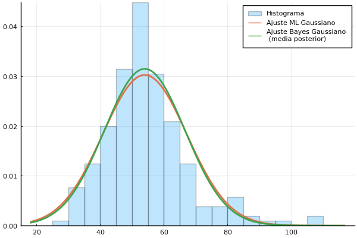

```julia
p
```

### Teorema de Bernstein-von Misses

En un modelo paramétrico $\left\{ P_{\pmb{\theta}} ,\, \theta \in \Theta\right\}$ donde cada $P_{\pmb{\theta}$ es una ley de probabilidad y $\Theta\subset \mathbb{R}^d$ para algún entero positivo $d$, bajo condiciones de regularidad si $X_1,\ldots , X_n\stackrel{\text{i.i.d.}}{\sim} P_{\pmb{\theta}_0}$, para un $\pmb{\theta}_0\in\Theta$ fijo,

$$ \| P_{ \pmb{\theta} \, | \, X_1,\ldots , X_n}(\cdot) - P_{\text{Normal}\left( \hat{\pmb{\theta}}_n,\, \left(n\mathcal{I}(\pmb{\theta}_0)\right)^{-1}\right)}(\cdot) \|_{TV} \to 0 $$

con $\hat{\pmb{\theta}}_n$ cualquier estimador eficiente de $\pmb{\theta}_0$ (por ejemplo el estimador máximo verosimil) y $\mathcal{I}(\pmb{\theta})$ la matriz de información de Fisher en $\pmb{\theta}$.

[figure not shown]

### Interpretación de la probabilidad frecuentista vs. Bayesiana

1) Frecuentista

- Las probabilidades son frecuencias relativas límite.
- Las probabilidades son propiedades objetivas de los fenómenos del mundo real.
- Las probabilidades se asignan a eventos relacionados a datos que presentan variación aleatoria.

2) Bayesiana

- Las probabilidades describen grados de creencia o incertidumbre.
- Las probabilidades son propiedades subjetiva de nuestras creencias.
- Las probabilidades se asignan no solamente a eventos relacionados a datos que presentan variación aleatoria sino a cualquier cantidad de interés.

#### Diferencia fundamental entre el método frecuentista y Bayesiano

1) Frecuentista

- Existe una ley de probabilidad determinista desconocida $P_0$ tal que $\left\{ X_i \right\}_{i=1}^\infty \stackrel{\text{i.i.d.}}{\sim}P_0$
- En un contexto paramétrico, hay una variable determinista desconocida $\theta_0$ tal que $\left\{ X_i \right\}_{i=1}^\infty \stackrel{\text{i.i.d.}}{\sim}P_{\theta_0}$.

2) Bayesiana

- Existe una ley de probabilidad aleatoria $P$ cuya distribución de probabilidad refleja nuestros grados de creencia a priori.
- En un contexto paramétrico, asignamos una ley de probabilidad $\Pi$ sobre $\theta$, i.e. $\theta\sim \Pi$, a la cual llamamos "distribución a priori". Los datos observados tienen distribución dada por $\left\{ X_i \right\}_{i=1}^\infty \, | \, \theta \stackrel{\text{i.i.d.}}{\sim}P_\theta$.

### Aspectos metodológicos

#### Aspectos metodológicos

1) Frecuentista

- Se diseñan métodos tales que si el tamaño de los datos observados tiende a infinito entonces el modelo probabilístico infiere frecuencias bien definidas, es decir propiedades de consistencia.
- Se cuantifica la incertidumbre mediante aproximaciones asintóticas (en el número de observaciones) o métodos Bootstrap.

2) Bayesiana

- Se realiza inferencia mediante la regla de Bayes que actualiza la distribución de los parámetros de interés condicionada a los datos observados.
- Se cuantifica la incertidumbre mediante la distribución posterior, especialmente haciendo uso de simulaciones posteriores para hacer cálculos Monte-Carlo. En caso de modelos no conjugados suele utilzarse el método MCMC.

### Ejemplo Regresión Lineal Bayesiana

\begin{align*} \sigma^2 \,&\sim \text{Inverse-Gamma}(\alpha_0,\beta_0) \\ \pmb{\beta}\,|\,\sigma^2 \,&\sim \text{Normal}(\pmb{\mu}_0,\sigma^2\pmb{\Lambda}_0^{-1}) \\ \pmb{y}\,|\,\pmb{\beta},\sigma^2,\hat{\pmb{X}} \,&\sim \text{Normal}(\hat{\pmb{X}}\pmb{\beta},\sigma^2\pmb{I}_n) \end{align*}

Entonces $p(\pmb{\beta},\sigma^2\,|\,\pmb{y})=\text{Normal}(\pmb{\mu}_n,\sigma^2\pmb{\Lambda}_n^{-1})\text{Inverse-Gamma}(\alpha_n,\beta_n)$ con

\begin{align*} \pmb{\Lambda}_n & = \hat{\pmb{X}}'\hat{\pmb{X}} + \pmb{\Lambda}_0 \\ \pmb{\mu}_n & = \pmb{\Lambda}_n^{-1} \left( \hat{X}'\pmb{y} + \pmb{\Lambda}_0\pmb{\mu}_0 \right) \\ \alpha_n & =\alpha + \frac{n}{2} \\ \beta_n & = \beta + \frac{1}{2}\left( \pmb{y}'\pmb{y} + \pmb{\mu}_0'\pmb{\Lambda}_0\pmb{\mu}_0 - \pmb{\mu}_n'\pmb{\Lambda}_n\pmb{\mu}_n \right) \end{align*}

```julia
# Ejemplo: datos extensión capa polar norte
seaice = CSV.read("../Datasets/mi_yearlyseaicenorth.csv", DataFrame)
```

45×2 DataFrame

20 rows omitted

| Row | year Int64 | extent_north Float64 |
| --- | --- | --- |
| 1 | 1979 | 12.4367 |
| 2 | 1980 | 12.2908 |
| 3 | 1981 | 12.205 |
| 4 | 1982 | 12.3842 |
| 5 | 1983 | 12.3958 |
| 6 | 1984 | 11.9975 |
| 7 | 1985 | 11.9958 |
| 8 | 1986 | 12.1742 |
| 9 | 1987 | 12.27 |
| 10 | 1988 | 12.1871 |
| 11 | 1989 | 12.0242 |
| 12 | 1990 | 11.7442 |
| 13 | 1991 | 11.8 |
| ⋮ | ⋮ | ⋮ |
| 34 | 2012 | 10.4633 |
| 35 | 2013 | 10.8592 |
| 36 | 2014 | 10.7842 |
| 37 | 2015 | 10.6367 |
| 38 | 2016 | 10.3233 |
| 39 | 2017 | 10.3225 |
| 40 | 2018 | 10.3408 |
| 41 | 2019 | 10.2608 |
| 42 | 2020 | 10.2083 |
| 43 | 2021 | 10.47 |
| 44 | 2022 | 10.7167 |
| 45 | 2023 | 10.4883 |

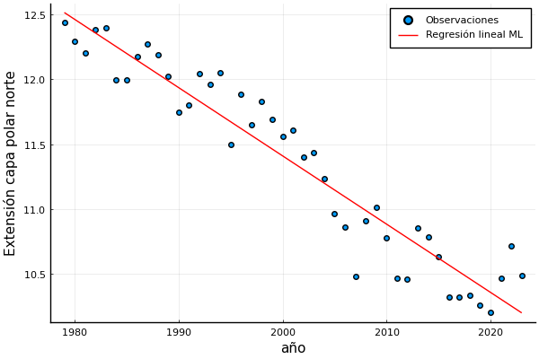

```julia
plt
```

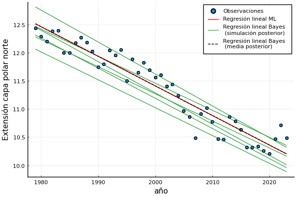

```julia
plt
```

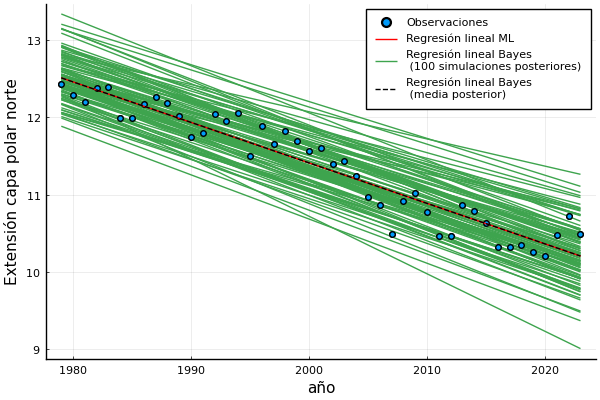

```julia
plt
```

### Ejemplo Regresión no Lineal con Stan (MCMC hamiltoniano)

\begin{align*} \pmb{\beta} \,&\sim \text{MvNormal}(\pmb{b}_0,\pmb{I}_3) \\ \sigma^2 \,&\sim \text{TruncatedNormal}(\mu_0,\sigma^2_0,a,b) \\ y_i\,|\,\pmb{\beta},\sigma^2,X_i \,&\stackrel{\text{i.i.d.}}{\sim} \text{Normal}\left(\mu\left( \pmb{\beta},X_i\right),\sigma^2\right) \end{align*}

con

$$ \mu(\pmb{\beta},x) = \frac{\beta_3}{1+e^{-\beta_1-\beta_2 x}}. $$

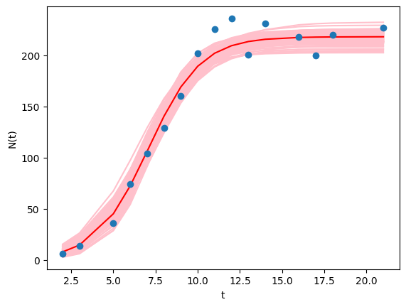

```julia
fig
```

### Ejemplo Regresión logística con Stan (MCMC hamiltoniano)

\begin{align*} \\ \pmb{\beta} \,&\sim \text{MvNormal}(\pmb{\mu}_0,\sigma^2_0\pmb{I}_p) \\ y_i\,|\,\pmb{\beta},\pmb{X}_i \,&\stackrel{\text{i.i.d.}}{\sim} \text{Bernoulli}\left( p(\pmb{\beta},\pmb{X}_i) \right) \end{align*}

```julia
# Cargamos datos de default
df
```

|  | rownames | default | student | balance | income |
| --- | --- | --- | --- | --- | --- |
| 0 | 1 | No | No | 729.526495 | 44361.625074 |
| 1 | 2 | No | Yes | 817.180407 | 12106.134700 |
| 2 | 3 | No | No | 1073.549164 | 31767.138947 |
| 3 | 4 | No | No | 529.250605 | 35704.493935 |
| 4 | 5 | No | No | 785.655883 | 38463.495879 |
| ... | ... | ... | ... | ... | ... |
| 9995 | 9996 | No | No | 711.555020 | 52992.378914 |
| 9996 | 9997 | No | No | 757.962918 | 19660.721768 |
| 9997 | 9998 | No | No | 845.411989 | 58636.156984 |
| 9998 | 9999 | No | No | 1569.009053 | 36669.112365 |
| 9999 | 10000 | No | Yes | 200.922183 | 16862.952321 |

10000 rows × 5 columns

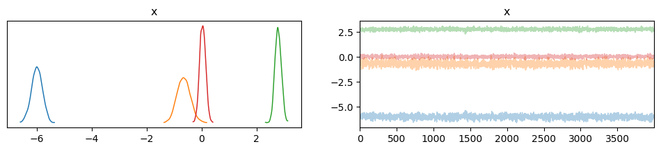

```julia
fig = az.plot_trace(β, compact=False)
```

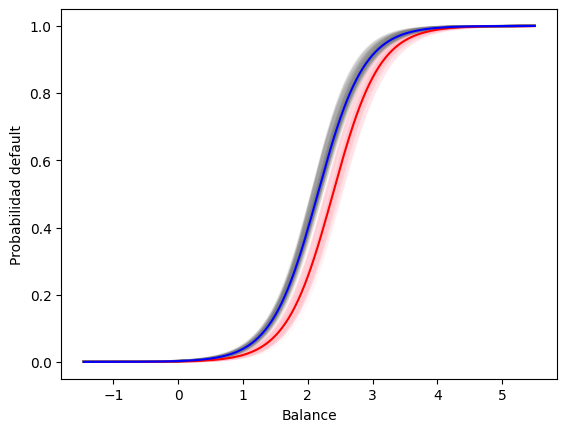

```julia
fig
```